# Survival Theory Course

Introduction and overview

Michael Sachs

# Structure of the course

# Learning outcomes

- Summarize basic asymptotic theory for processes and sketch derivations of basic results involving the empirical cumulative distribution function.
- Identify notation and terminology for counting processes and connect them to survival statistics.
- Reframe nonparametric estimators of survival quantities in terms of counting processes.
- Paraphrase the martingale central limit theorem and describe how it can be used to perform inference for the Kaplan-Meier estimator.
- Interpret the proportional hazards, additive hazards, and parametric regression models from the counting process perspective.
- Compare and contrast theoretical and methodological advances in survival analysis, including frailty models, multi-state models, joint models, causal inference and prediction for survival analysis.

# Weekly Schedule

- Lectures on Monday and Friday from 11-12. Exercises workshop Wednesday from 10-12, help available from 11-12.
- Lectures will be recorded and posted on canvas, workshop participation optional, if you want we can organize in-person sessions at KI.
- Post your exercise solutions on Canvas before the following Wednesday for feedback (use any format you like as long as it is legible)
1. Overview of the course. Counting process introduction, notation and terminology.
2. Martingale introduction, terminology, and limit theorems. Censoring, types, assumptions.
3. Representation of Nelson-Aalen and Kaplan-Meier Estimators. Asymptotic analysis. Logrank tests and variants, Confidence bands.
4. General regression models, likelihood and asymptotic analysis. Time dependent covariates and censoring assumptions.
5. Proportional hazards models, stratified models, residuals. Additive hazards models, relative survival.
6. Non martingale analysis using empirical process theory. Functional delta method and examples.
7. Parametric models, including AFT and flexible parametric, frailty (Andrea).
8. Multi state models introduction and regression. Competing risks and illness death models (Therese).
9. Causal inference, pseudo-observations, multiple time scales, recurrent events.
10. Individual study to work on projects.
11. Presentations of projects (Exam) – Week 21.

# Student seminars

- Each of you choose a topic in survival analysis
- Study the theory on that topic from the counting process perspective (we will suggest resources)
- Prepare a 20 minutes presentation for that day or a 4 page paper summarizing the topic
- Topics:
  1. Recurrent events/Andersen-Gill model
  2. Multi-state models
  3. Joint longitudinal and survival models
  4. Pseudo-observation regression
  5. Choose your own

# General philosophy and goal of this course

- Not going to dwell on the mathematical formalism.
- Wade through the jargon and develop a general understanding of the theory
- What it means, why it is important, and how the theory is used to develop and evaluate methods

### Questions?

# Review of classicial asymptotics

# Simple statistics

In Theory I, and maybe before, you studied *finite-dimensional* parameters and estimators of them.

Consider a random sample $X_1, X_2, \ldots, X_n$ from some unspecified distribution $F$ and an estimator:

$$\hat{\mu}_n = T(X_1, \ldots, X_n),$$

where $T$ is a mapping from $\mathbb{R}^n$ to $\mathbb{R}$, i.e., a function from the sample to the real line.

You studied the asymptotic behavior of $\hat{\mu}_n$, what happens when $n \rightarrow \infty$. Why asymptotics?

# Modes of convergence

1. In probability: $\hat{\mu}_n \rightarrow_p \mu$ if $\lim_{n \rightarrow \infty} P(|\hat{\mu}_n - \mu| < \varepsilon) = 1$ for every $\varepsilon$.
2. Almost surely: $\hat{\mu}_n \rightarrow_{as} \mu$ if $P(\lim_{n \rightarrow \infty}|\hat{\mu}_n - \mu| < \varepsilon) = 1$ for every $\varepsilon$.
3. In distribution $\hat{\mu}_n \rightarrow_d M$ if the cumulative distributions functions $F_n$ of $\hat{\mu}_n$ and $F_M$ of $M$ satisfy $\lim_{n\rightarrow \infty} F_n(x) = F_M(x)$ for every continuity point $x$ of $F_M$

**How do we prove such things for specific statistics?**

### From basic principles

1. Make some assumptions about $F$, e.g., finite mean, finite variance
2. Work with moment generating functions or characteristic functions instead of CDFs
3. Manipulate the expressions in the definitions, apply a known or previously proven *inequality* (Chebychev, Hölder, Minkowski etc.)
4. Apply basic results from real analysis/calculus, e.g., $\lim_{n\rightarrow \infty} \frac{1}{n} = 0$

# Tools of the (statistician) trade

Once some basic convergence results have been established, there are a number of theorems that serve as building blocks for more complex results.

1. Cramér-Wold device: a $k$ dimensional statistic converges in distribution if and only if all possible linear combinations of it converge in distribution.
2. Continuous mapping theorem: if $g: \mathbb{R}^m \rightarrow \mathbb{R}$ is continuous and $\hat{\mu}_n \rightarrow_{p,d,as} \mu$, then $g(\hat{\mu}_n) \rightarrow_{p,d,as} g(\mu)$.
3. Slutsky’s theorem: if $A_n \rightarrow_p a$ and $B_n \rightarrow_p b$, with $a,b$ constants, and $\hat{\mu}_n \rightarrow_{d} \mu$, then $A_n\hat{\mu}_n + B_n \rightarrow_{d} a\mu + b$.
4. The delta method: suppose $g: \mathbb{R}^m \rightarrow \mathbb{R}^k$ is differentiable with derivative $g'$, a $k \times m$ matrix and suppose
   $$Z_n = a_n(\hat{\mu}_n - \mu) \rightarrow_d Z.$$
   Then
   $$a_n(g(\hat{\mu}_n) - g(\mu)) \rightarrow_d g'(\mu) Z.$$

… and many more results that can go a long way.

# Some notes on notation

We will often write $\int_\Omega \, dF_X$ to mean the integral with respect to the distribution $F_X$ and it equals $P(X \in \Omega)$ where $X$ has distribution $F_X$.

Likewise $\int f\, dF_X$ means the expectation of $f(X)$ or $E[f(X)]$ where $X \sim F_X$.

When applied to the empirical measure $\mathbb{F}_n$ for a sample $X_1, \ldots, X_n$ from $F_X$, then $\int f \, d\mathbb{F}_n = \frac{1}{n}\sum_{i = 1}^nf(X_i)$.

$F(x-)$ denotes the left-hand limit $\lim_{t \uparrow x} F(t)$, and $F(x+)$ the right-hand limit.

$dF(t)$ denotes the increment $F(t + dt) - F(t)$, and $\Delta A_i$ the increment for discrete cases $A_{i+1} - A_i$.

# The process point of view

# What is a process?

A stochastic *process* is a collection of random variables with an *index*.

An *empirical process* is a process computed from data.

Example, consider our random sample $X_1, \ldots, X_n$ from distribution $F$. The empirical cdf is
$$\mathbb{F}_n(t) = \frac{1}{n}\sum_{i = 1}^n I\{X_i \leq t\}.$$
This is a *random function* or *sample path*. We can view it as the collection of random variables $\{\mathbb{F}_n(t): t \in \mathbb{R}\}$.

Our statistic $T(X_1, \ldots, X_n)$ is now is a mapping from $\mathbb{R}^n$ to the *space of bounded increasing functions*.

# Analysis

How can we analyze the behavior of $\mathbb{F}_n(t)$?

For each fixed $t \in \mathbb{R}$ the laws of large numbers tells us that

$\mathbb{F}_n(t) \rightarrow_p F(t)$,

and the central limit theorem tells us that

$\sqrt{n}(\mathbb{F}_n(t) - F(t)) \rightarrow_d N(0, F(t)(1 - F(t)))$.

For $T_k = \{t_1, \ldots t_k\}$ a finite collection of $t$s the random vector of ecdfs evaluated at $T_k$ converges in distribution to a mean zero Gaussian vector with covariance $F(s \wedge t) - F(s) F(t)$ for $s, t \in T_k$, where $s \wedge t = \min\{s, t\}$.

Thinking about the random function, what other modes of convergence can we consider?

# Uniform convergence

Glivenko-Cantelli in 1933, proved something like

$$\sup_t|\mathbb{F}_n(t) - F(t)| \rightarrow_{as} 0,$$
as $n \rightarrow \infty$. This is called *uniform convergence* of the sample paths.

This is also written as

$$\| \mathbb{F}_n - F \|_\infty \rightarrow_{as} 0,$$
and this highlights the fact that the process point of view uses different notions of distance, since we are now in a *functional space* rather than Euclidean space. We will see later that this requires different notions of differentiability.

# Proof sketch

For any $\varepsilon > 0$, there exists a partition $-\infty = t_0, t_1, \ldots, t_m = \infty$ such that $F(t_j) - F(t_{j-1}) < \varepsilon$ for all $j$. Then noting that

$\mathbb{F}_n(t) - F(t) \leq \mathbb{F}_n(t_j) - F(t_{j-1})$ $= \mathbb{F}_n(t_j) - F(t_{j-1}) + F(t_j) - F(t_j) = \mathbb{F}_n(t_j) - F(t_{j}) + \varepsilon$.

and

$\mathbb{F}_n(t) - F(t) \geq \mathbb{F}_n(t_j) - F(t_{j}) - \varepsilon$, we have
$$\|\mathbb{F}_n - F \|_\infty \leq \max_{j}|\mathbb{F}_n(t_j) - F(t_j)| + \varepsilon.$$
The first term converges to 0 almost surely by the strong law of large numbers, and thus for any $m$, we can find an $N$ such that for all $n \geq N$,

$$\sup_{m\geq n}\| \mathbb{F}_m - F \|_\infty \leq \varepsilon.$$
Since $\varepsilon$ was arbitrary, the result follows.

# Some details

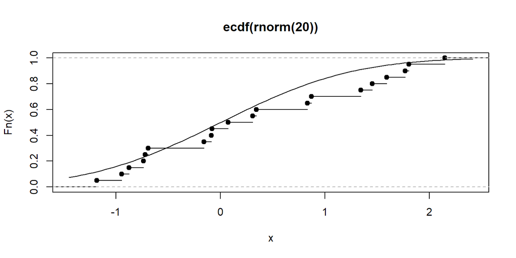

- For any $\varepsilon > 0$, we can find a partition of the range such that the largest jump size is still less than $\varepsilon$. In the case of semi-continuous distributions, jumps larger than that occur with probability 0 (it must be a finite set of discontinuities)
- Use that partition to convert the problem to the finite dimension, and use the classical results combined with some calculus.

# Convergence in distribution

Given the classical finite dimensional result, we might surmise that $\sqrt{n}(\mathbb{F}_n - F)$ converges to some sort of Gaussian process with mean 0 and covariance $F(s \wedge t) - F(t)F(s)$.

Donsker proved just that in 1952, and made more general/rigorous by Skorokod and Kolmogorov in 1956.

# A closer look at processes

# Gaussian processes

It is useful to consider the case where $F(t) = t$, i.e., the random variables are uniform on $[0, 1]$. The Gaussian process $\{\mathbb{U}(t), t \in [0, 1]\}$ with mean function $E(\mathbb{U}(t)) = 0$ and
$$Cov(\mathbb{U}(s), \mathbb{U}(t)) = s \wedge t - st$$
is called a *Brownian bridge*.

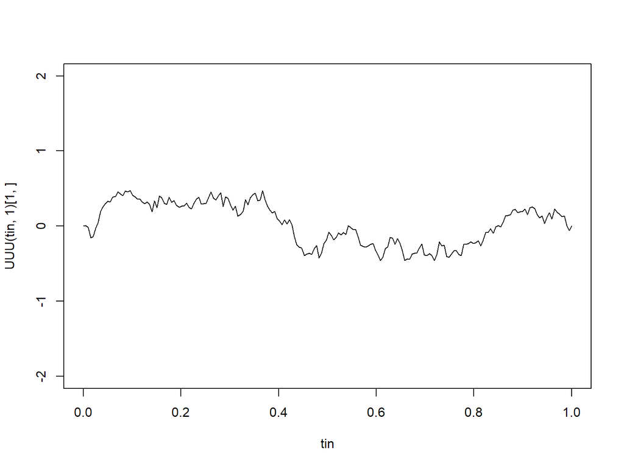

```r
library(mvtnorm)

UUU <- function(tt, n) {

    rmvnorm(n, mean = rep(0, length(tt)),
            sigma = outer(tt, tt, function(s, t) pmin(s, t) - s * t))

}

tin <- seq(0, 1, length.out = 200)
plot(UUU(tin, 1)[1,] ~ tin, type = "l", ylim = c(-2, 2))
```

# Brownian motion

If a Gaussian process $\mathbb{S}$ has mean 0 and covariance function
$$Cov(\mathbb{S}(s), \mathbb{S}(t)) = s \wedge t$$
it is called a *Brownian motion* or also a *Weiner process*.

Note that if $\mathbb{U}$ is a Brownian bridge and $Z$ an independent standard normal random variable, then
$$\mathbb{U}(t) + t Z, \mbox{ for } t \in [0, 1]$$
is a Brownian motion. Likewise, if $\mathbb{S}$ is a Brownian motion, then $\mathbb{S}(t) - t \mathbb{S}(1)$ is a Brownian bridge for $t \in [0, 1]$.

# Increments of a process

The increment of a process $X$ is defined as $X(t + u) - X(t)$ for $u \geq 0$. We will often write $d\, X(t)$ to represent the increment $X(t + dt) - X(t)$, i.e., the thing that happens just after $t$.

### Exercises/factoids

1. The Brownian motion has independent increments with distributions $\mathbb{S}(t + u) - \mathbb{S}(t) \sim N(0, u)$. (This is called *stationary*).
2. The Brownian motion can be characterized by the fact that $E(d\, \mathbb{S}(t))$ does not depend on previous values. This makes it a type of *martingale*, which we will study in more detail later.
3. The Brownian bridge does *not* have independent increments.

# The Poisson process

A counting process is written as $\{N(t), t \geq 0\}$, where $N(0) = 0$, and $N(t)$ counts the number of events that occur up to time $t$.

$N(t)$ is a Poisson process if it has independent increments (counts on disjoint subsets of $\mathbb{R}^+$ are independent) and the count on an interval of length $t$ is distributed Poisson with rate $\lambda t$. It has some interesting properties:

- The number of events in any finite interval is Poisson, and only depends on the length of the interval
- The time differences between events is distributed Exponential with parameter $1/\lambda$
- The *compensated process* $M(t) = N(t) - t\lambda$ is a martingale since its expected next value is the current one (we will make this more rigorous later)

# Summary

# Why processes?

- Lots of theory has been developed for stochastic processes in general.
- Statistical methods for survival analysis can be analyzed in a unified manner using this general theory.
- That is the focus of this course.

### Homework and reading

The exercises should be a review of things you’ve seen before. If you struggle with the terminology or notation, consider brushing up on basic asymptotic statistics (ask me for recommendations).

Reading for Friday: ABG Chapter 1.